# Quarteto de Anscombe

## 2.2 Gráficos com escala logarítimica.

A partir desses gráficos aprendemos a utilizar a função scale_x_log10(), que faz os valores de x evoluirem exponencialmente, demostrando ainda mais uma maior correlação entre as variáveis.

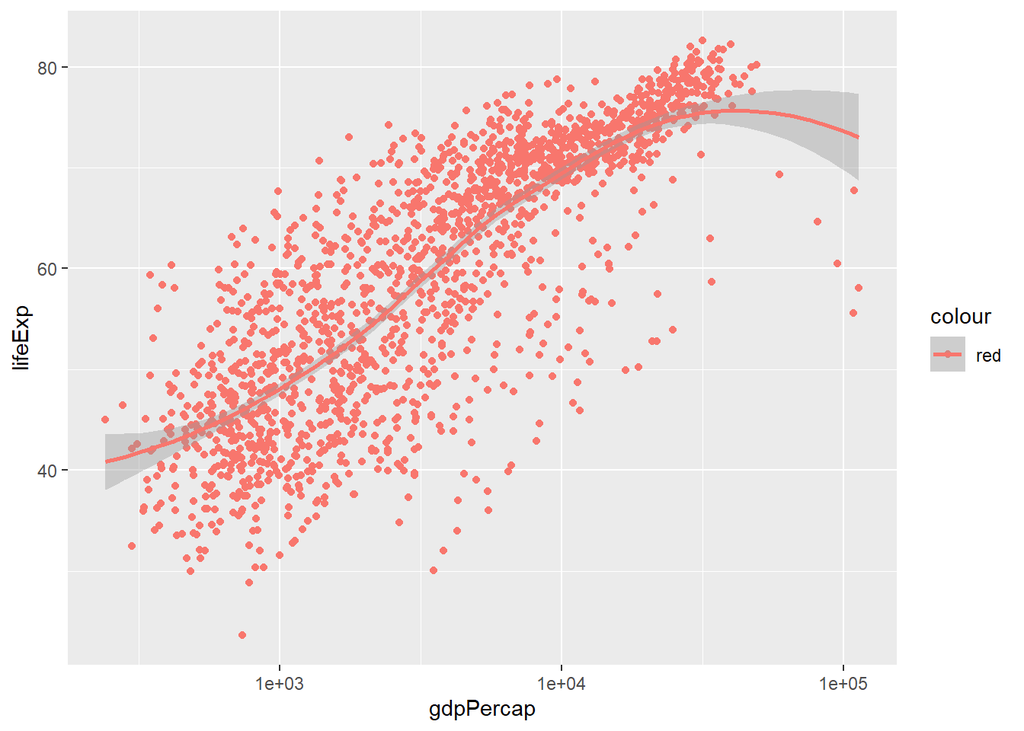

```r
graph1 <- ggplot(gapminder, aes(x = gdpPercap, y = lifeExp, color = 'red'))

graph1 + geom_point() +
  geom_smooth(method = "loess") +
  scale_x_log10()
```

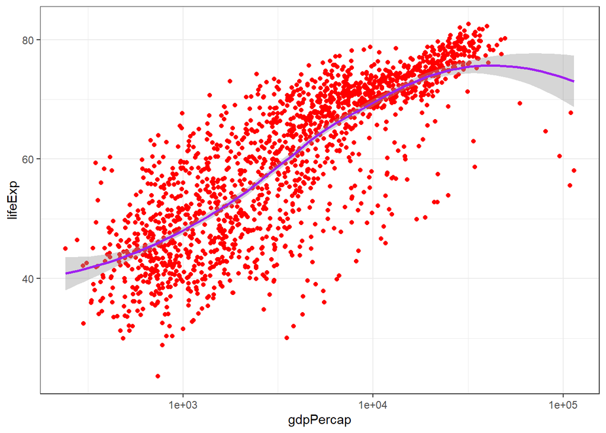

```r
graph1 + geom_point(color = 'red') +
  geom_smooth(method = "loess", color = 'purple') +
  scale_x_log10() +
  theme_bw()
```

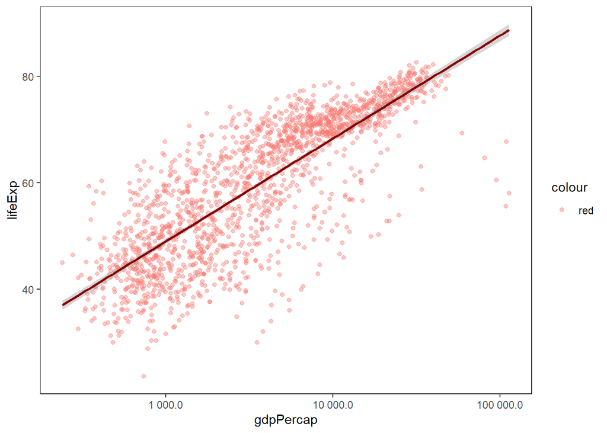

```r
graph1 + geom_point(alpha = 0.4) +
  geom_smooth(method = "lm", color = "darkred") +
  scale_x_log10() +
  theme_bw() +
  scale_x_log10(labels = scales::label_number(scale = 1, accuracy = 0.1, prefix = "", suffix = "")) +
  theme(panel.background = element_rect(fill = "white"),
        panel.grid.major = element_blank(),
        panel.grid.minor = element_blank())
```

## 2.3 Gráfico com distinção

Nesses gráficos agora há uma divisão entre os continentes por cores. Assim, nos é possível observar quais são as diferenças em cada continente em específico.

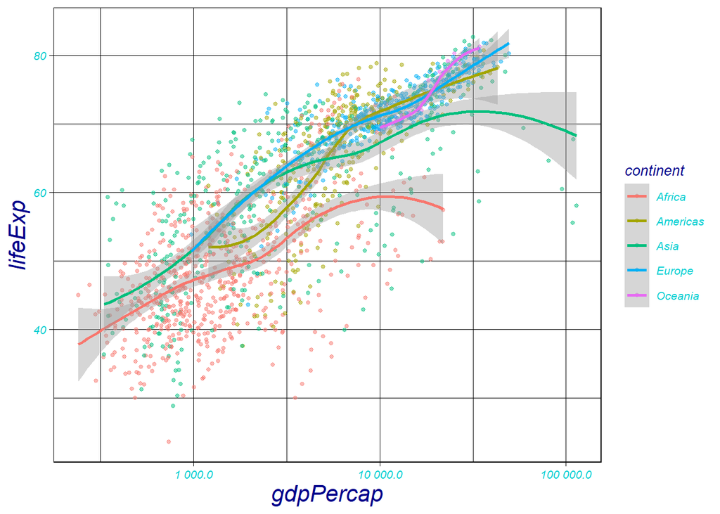

```r
graph2 <- ggplot(gapminder, aes(x = gdpPercap, y = lifeExp, color = continent))

graph2 + geom_point(alpha = 0.5, size = 1) +
  geom_smooth(method = "loess") +
  scale_x_log10(labels = scales::label_number(scale = 1, accuracy = 0.1, prefix = "", suffix = "")) +
  theme_linedraw() +
  theme(
      text = element_text(
        size = 10,
        face = "italic",
        color = "darkblue"
      ),
      legend.text = element_text(color = "darkturquoise", size = 8),
      axis.text.x = element_text(size = 8, color = "darkturquoise"), axis.title.x = element_text(size = 16),
      axis.text.y = element_text(size = 8, color = "darkturquoise"), axis.title.y = element_text(size = 16)
    )
```

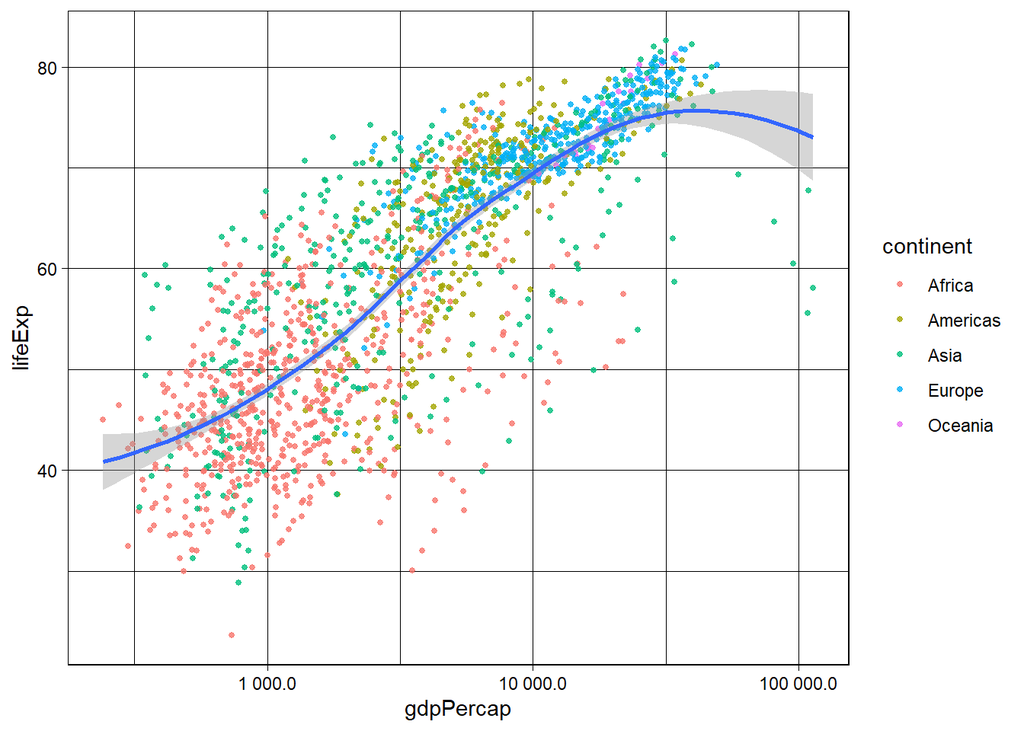

```r
graph3 <- ggplot(gapminder, aes(x = gdpPercap, y = lifeExp)) +
  geom_point(alpha = 0.8, size = 1, aes(color = continent)) +
  geom_smooth(method = "loess") +
  scale_x_log10(labels = scales::label_number(scale = 1, accuracy = 0.1, prefix = "", suffix = "")) +
  theme_linedraw()

graph3
```

## 2.4 Gráficos com alterações nos valores

Aqui temos dois novos gráficos. O segundo, para deixar mais claro ao leitor, a legenda do gdp foi colocar na escala de doláres. Com a mudança na forma de exibição dos valores de x, o gráfico torna-se mais fácil de ler.

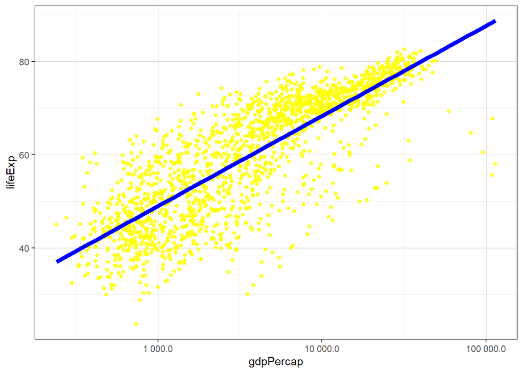

```r
graph4 <- ggplot(gapminder, aes(x = gdpPercap, y = lifeExp)) +
  geom_point(color = "yellow", alpha=0.8) +
  geom_smooth(method = "lm", se = FALSE, fullrange = TRUE, color = "blue", size = 2, alpha = 0.1) +
  scale_x_log10(labels = scales::label_number(scale = 1, accuracy = 0.1, prefix = "", suffix = "")) +
  theme_bw() +
  theme(panel.grid.major = element_line(colour = "gray80", size = 0.2))
graph4
```

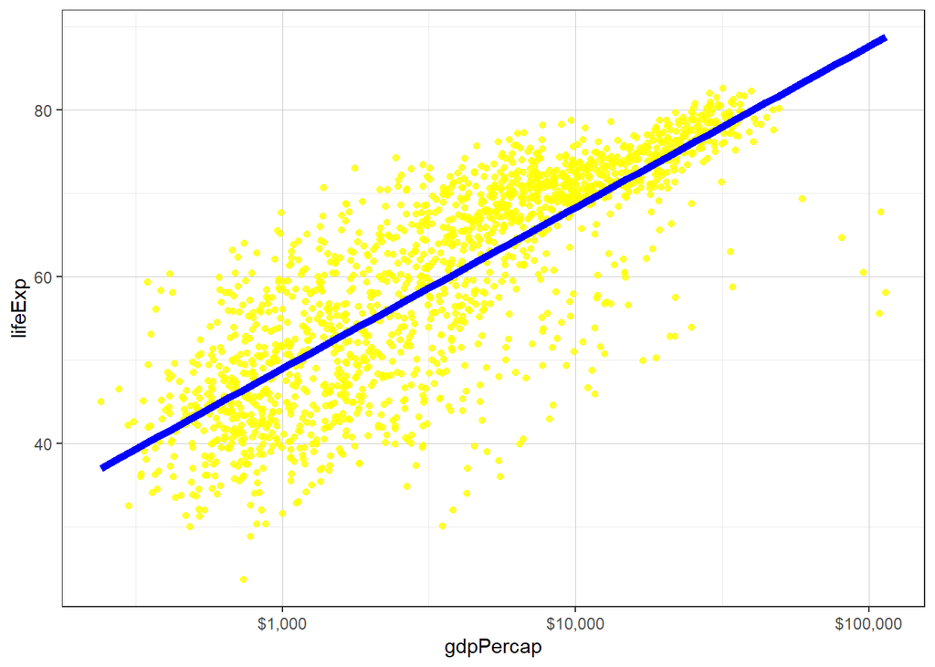

```r
graph4 + scale_x_log10(labels=scales::dollar)
```

## 2.5 Gráficos com gradiente de população

Já, por último, esse gráfico faz um gradiente com a diferença de população através de um gradiente de cores. Assim, analisamos mais uma variável além do gdp e da expectativa de vida em uma imagem apenas.

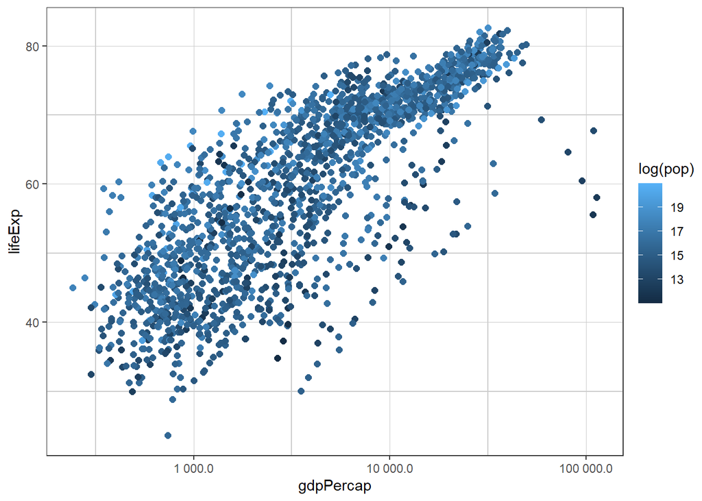

```r
graph5 <- ggplot(gapminder, aes(x = gdpPercap, y = lifeExp)) +
  geom_point(size = 2, aes(color = log(pop))) +
  scale_x_log10() +
  theme_test() +
  scale_x_log10(labels = scales::label_number(scale = 1, accuracy = 0.1, prefix = "", suffix = "")) +
  theme(panel.grid.major = element_line(color = "gray80", size = 0.2),
        panel.grid.minor = element_line(color = "gray80"))

graph5
```

# 3 Conclusão

Essa versão foi como fazer a parte A, então não encontrei tanta dificuldade. A parte mais díficil foi estilizar um pouco mais os gráficos e fazê-los melhores de ser compreendidos. Os temas (como theme_bw()) foram muito úteis.

[figure not shown]